# CENG 4515 DATA SCIENCE AND ANALYTICS-HW2

İrem Uslu

2022-11-17

## Importing libraries

```r
  library(ggplot2)
  library(tidyverse)
  library(dplyr)
  library(plyr)
  library(caret)
  library(corrplot)
  library(ROCR)
  library(Rcpp)
  library(gmodels)
  library(pROC)
  library(InformationValue)
  library(factoextra)
  library(car)
```

### Dowload the “mole_dataset.csv” and data preprocessing.

```r
mole <- read.csv("mole_dataset.csv" , header=TRUE , sep=",")

mole$sex <- NULL
mole$X <- NULL
mole$image_id <- NULL


mole$benign_malignant <-  factor(mole$benign_malignant)
summary(mole)
```

```
##     pixels_x       pixels_y    clin_size_long_diam_mm full_img_size
##  Min.   : 640   Min.   : 480   Min.   : 1.60          Min.   :  24653
##  1st Qu.:1024   1st Qu.:1024   1st Qu.: 5.00          1st Qu.:  82799
##  Median :1908   Median :1874   Median : 6.90          Median : 294916
##  Mean   :2347   Mean   :1765   Mean   : 6.85          Mean   : 336247
##  3rd Qu.:3264   3rd Qu.:2448   3rd Qu.: 8.60          3rd Qu.: 534130
##  Max.   :6000   Max.   :4000   Max.   :19.30          Max.   :1907816
##                                NA's   :21
##    age_approx    non_overlapping_rate    corners             red
##  Min.   :10.00   Min.   :  0.00       Min.   :   0.00   Min.   :  1.856
##  1st Qu.:45.00   1st Qu.: 54.85       1st Qu.:  31.75   1st Qu.:126.920
##  Median :60.00   Median :117.44       Median :  60.00   Median :169.268
##  Mean   :58.23   Mean   :112.44       Mean   : 131.10   Mean   :154.797
##  3rd Qu.:70.00   3rd Qu.:170.12       3rd Qu.: 121.25   3rd Qu.:196.417
##  Max.   :85.00   Max.   :200.00       Max.   :2280.00   Max.   :235.494
##  NA's   :1                                              NA's   :20
##      green              blue          benign_malignant
##  Min.   :  1.857   Min.   :  1.856   benign   :200
##  1st Qu.: 71.196   1st Qu.: 57.453   malignant:200
##  Median :118.271   Median :101.873
##  Mean   :109.947   Mean   : 99.254
##  3rd Qu.:152.204   3rd Qu.:141.570
##  Max.   :223.031   Max.   :213.756
##  NA's   :20        NA's   :20
```

### Correlation matrix and heatmap between independent variables.

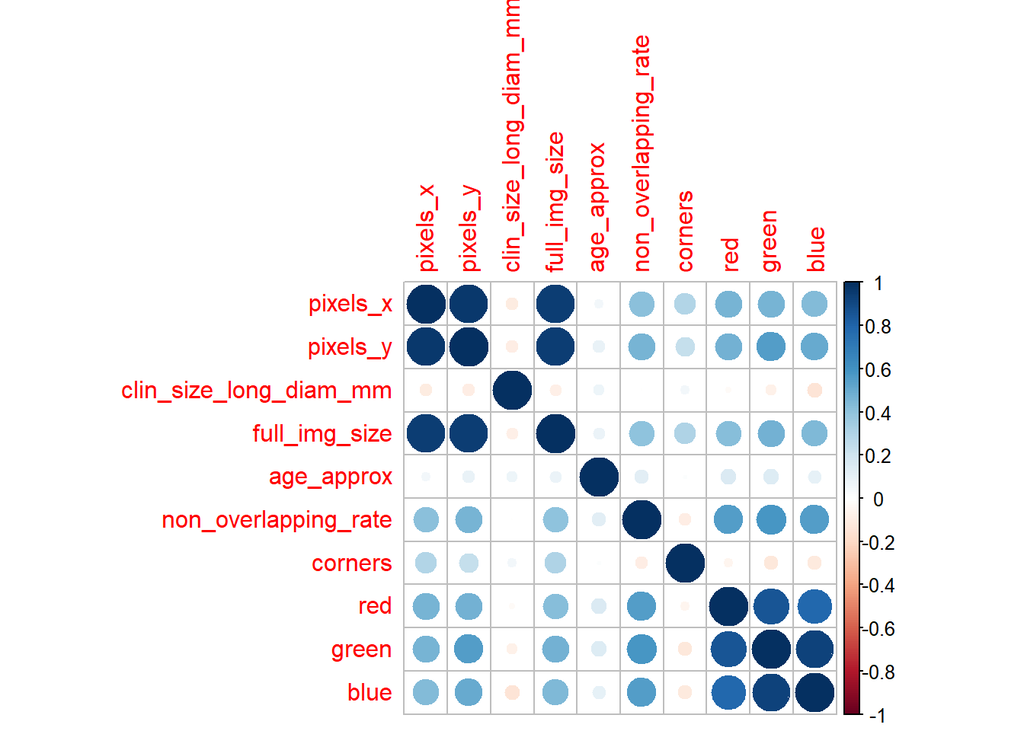

```r
mole <- na.omit(mole)
cor <- cor(mole[,1:10])
corrplot(cor,method = "circle")
```

Dark blue dots have strong positive correlations. For example, it can be said that there is a strong relationship between the x and y pixels and the full size of the image. Or it can be said that the x and y pixels have a weak positive relationship with the vertices.

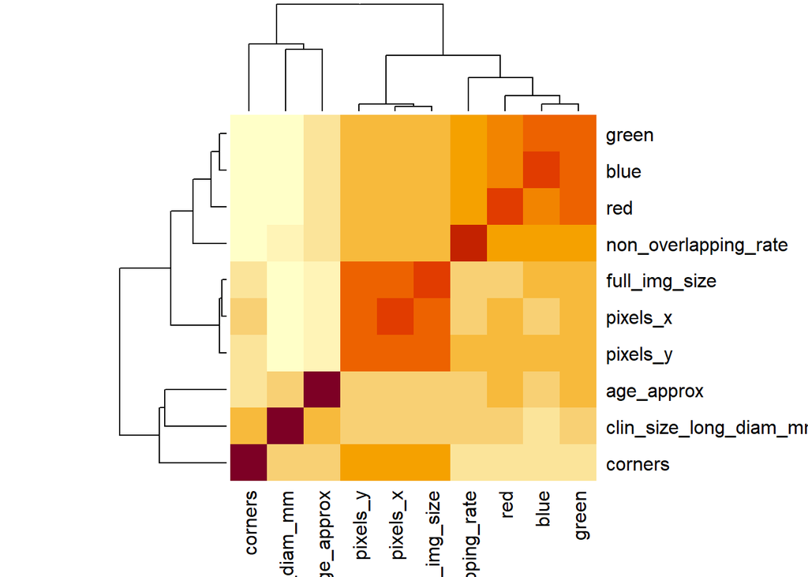

```r
heatmap(cor(mole[,-11]))
```

It can be said that there is an increasing relationship from the corners variable to the green variable.

### Build a logistic regression model to raw data first.Train and test dataset are created.

```r
#Malignant and benign numbers were checked for logistic regression.
dataMalignant <- mole %>%
                filter(benign_malignant=="malignant")
                nrow(dataMalignant)
```

```
## [1] 171
```

```r
dataBenign <- mole %>%
              filter(benign_malignant=="benign")
              nrow(dataBenign)
```

```
## [1] 188
```

```r
set.seed(100)
dataMalignantIndex <- sample(1:nrow(dataMalignant) , size= 0.70*nrow(dataMalignant))

dataBenignIndex <- sample(1:nrow(dataBenign) , size= 0.70*nrow(dataMalignant))



# Train dataset was created.
trainMalignant <- dataMalignant[dataMalignantIndex,]
trainBenign <- dataBenign[dataBenignIndex,]

trainSet <- rbind(trainMalignant , trainBenign)
table(trainSet$benign_malignant) #Malignant and benign values were equalized.
```

```
##
##    benign malignant
##       119       119
```

```r
# Test dataset was created.
testMalignant <- dataMalignant[-dataMalignantIndex,]
testBenign <- dataBenign[-dataBenignIndex,]

testSet <- rbind(testMalignant , testBenign)
table(testSet$benign_malignant)
```

```
##
##    benign malignant
##        69        52
```

```r
model <- glm(benign_malignant~.,family="binomial", data=trainSet)
summary(model)
```

```
##
## Call:
## glm(formula = benign_malignant ~ ., family = "binomial", data = trainSet)
##
## Deviance Residuals:
##      Min        1Q    Median        3Q       Max
## -1.98684  -0.82317  -0.00065   0.72398   2.83283
##
## Coefficients:
##                          Estimate Std. Error z value Pr(>|z|)
## (Intercept)            -1.403e+00  1.044e+00  -1.344 0.178855
## pixels_x               -1.962e-03  8.751e-04  -2.242 0.024960 *
## pixels_y                1.499e-03  1.404e-03   1.068 0.285632
## clin_size_long_diam_mm  1.042e-01  5.701e-02   1.829 0.067456 .
## full_img_size           6.821e-07  2.025e-06   0.337 0.736306
## age_approx              4.487e-02  1.174e-02   3.823 0.000132 ***
## non_overlapping_rate   -7.932e-03  3.343e-03  -2.373 0.017665 *
## corners                 2.481e-03  8.943e-04   2.774 0.005541 **
## red                    -1.171e-02  8.996e-03  -1.302 0.192862
## green                   5.503e-02  1.674e-02   3.288 0.001008 **
## blue                   -3.779e-02  1.094e-02  -3.454 0.000553 ***
## ---
## Signif. codes:  0 '***' 0.001 '**' 0.01 '*' 0.05 '.' 0.1 ' ' 1
##
## (Dispersion parameter for binomial family taken to be 1)
##
##     Null deviance: 329.94  on 237  degrees of freedom
## Residual deviance: 234.49  on 227  degrees of freedom
## AIC: 256.49
##
## Number of Fisher Scoring iterations: 5
```

Variables such as age_approx, blue, green, non_overlapping_rate have a significant effect on determining the type of mole. However, pixel_y,red and full_img_size have no significant effect.

### Confusion Matrix

```r
prediction <- predict(model , testSet ,type="response")

cm <- confusionMatrix(testSet$benign_malignant , prediction)
cm
```

```
##   benign malignant
## 0     43        13
## 1     26        39
```

```r
accur <- (cm[1,1] + cm[2,2])/ sum(cm)
accur
```

```
## [1] 0.677686
```

43 benign and 39 malignant moles were predicted correctly.The accuracy rate of the model I created is 0.67. Correct predictions were made in the test data set at a rate of 0.67.

### Roc Curve

```r
rocModel <- roc(testSet$benign_malignant ~ prediction) #control = negative class , case = positive class
```

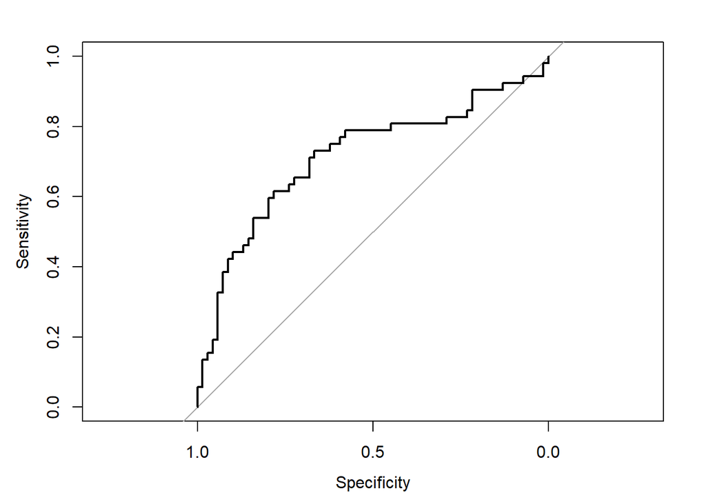

```r
plot(rocModel)
```

```r
rocModel
```

```
##
## Call:
## roc.formula(formula = testSet$benign_malignant ~ prediction)
##
## Data: prediction in 69 controls (testSet$benign_malignant benign) < 52 cases (testSet$benign_malignant malignant).
## Area under the curve: 0.7149
```

### Apply PCA

```r
molePr <- prcomp(mole[,-11] , scale=TRUE,center = TRUE)
summary(molePr)
```

```
## Importance of components:
##                           PC1    PC2    PC3     PC4    PC5     PC6     PC7
## Standard deviation     2.1621 1.3262 1.0510 0.94282 0.8283 0.71988 0.47509
## Proportion of Variance 0.4674 0.1759 0.1105 0.08889 0.0686 0.05182 0.02257
## Cumulative Proportion  0.4674 0.6433 0.7538 0.84268 0.9113 0.96311 0.98568
##                            PC8    PC9    PC10
## Standard deviation     0.26127 0.2470 0.11809
## Proportion of Variance 0.00683 0.0061 0.00139
## Cumulative Proportion  0.99251 0.9986 1.00000
```

I scaled and centered the data to standardize it.PC1 accounts for 46% of the total variance in the data.

### PCA plott and select best number of PCs for your data.

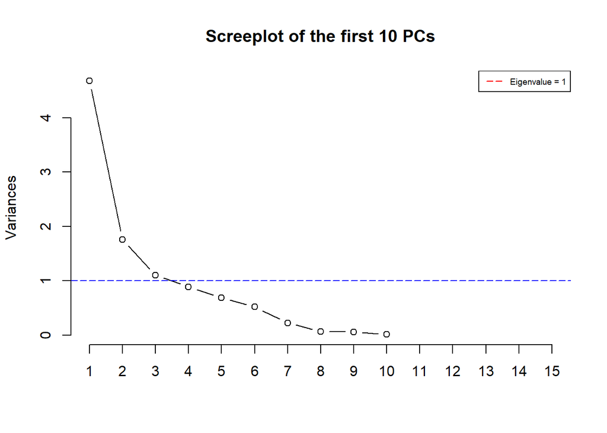

```r
screeplot(molePr, type = "l", npcs = 15, main = "Screeplot of the first 10 PCs")
abline(h = 1, col="blue", lty=5)
legend("topright", legend=c("Eigenvalue = 1"),
       col=c("red"), lty=5, cex=0.6)
```

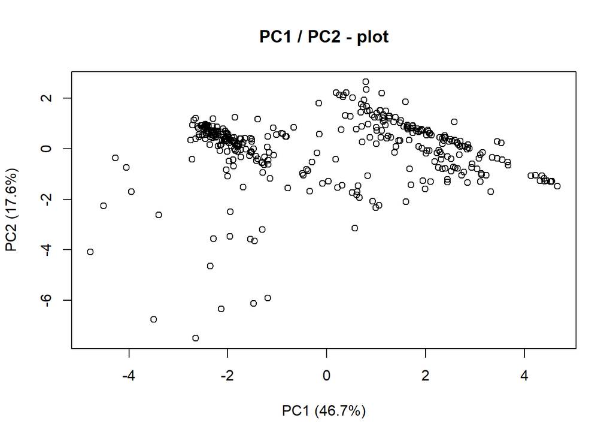

```r
plot(molePr$x[,1],molePr$x[,2], xlab="PC1 (46.7%)", ylab = "PC2 (17.6%)", main = "PC1 / PC2 - plot")
```

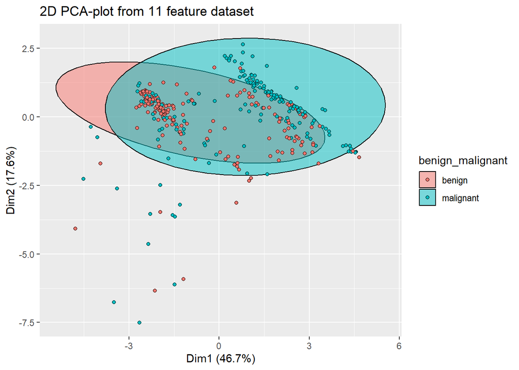

```r
ggplot(mole , aes(molePr$x[,1],molePr$x[,2],col=benign_malignant,fill=benign_malignant)) +
  stat_ellipse(geom = "polygon" , col="black",alpha=0.5)+
  geom_point(shape=21,col="black")+
  xlab("Dim1 (46.7%)")+
  ylab("Dim2 (17.6%)")+
  ggtitle("2D PCA-plot from 11 feature dataset")
```